# My Simple Logistic Regression

```r
Ad.lm <- glm(Clicked.on.Ad == "0" ~ Daily.Time.Spent.on.Site, data = Ad, family = "binomial")
```

## Background

A study was conducted on marketing strategies of advertisments within websites. Everything from time spent on the website to area income was collected. For our purposes, we’re going to look at the time spent on the website and whether or not the advertisment on screen was clicked on.

```r
datatable(Ad)
```

|  | Daily.Time.Spent.on.Site | Age | Area.Income | Daily.Internet.Usage | Ad.Topic.Line | City | Male | Country | Timestamp | Clicked.on.Ad |
| --- | --- | --- | --- | --- | --- | --- | --- | --- | --- | --- |
| 1 | 68.95 | 35 | 61833.9 | 256.09 | Cloned 5thgeneration orchestration | Wrightburgh | 0 | Tunisia | 2016-03-27 00:53:11 | 0 |
| 2 | 80.23 | 31 | 68441.85 | 193.77 | Monitored national standardization | West Jodi | 1 | Nauru | 2016-04-04 01:39:02 | 0 |
| 3 | 69.47 | 26 | 59785.94 | 236.5 | Organic bottom-line service-desk | Davidton | 0 | San Marino | 2016-03-13 20:35:42 | 0 |
| 4 | 74.15 | 29 | 54806.18 | 245.89 | Triple-buffered reciprocal time-frame | West Terrifurt | 1 | Italy | 2016-01-10 02:31:19 | 0 |
| 5 | 68.37 | 35 | 73889.99 | 225.58 | Robust logistical utilization | South Manuel | 0 | Iceland | 2016-06-03 03:36:18 | 0 |
| 6 | 59.99 | 23 | 59761.56 | 226.74 | Sharable client-driven software | Jamieberg | 1 | Norway | 2016-05-19 14:30:17 | 0 |
| 7 | 88.91 | 33 | 53852.85 | 208.36 | Enhanced dedicated support | Brandonstad | 0 | Myanmar | 2016-01-28 20:59:32 | 0 |
| 8 | 66 | 48 | 24593.33 | 131.76 | Reactive local challenge | Port Jefferybury | 1 | Australia | 2016-03-07 01:40:15 | 1 |
| 9 | 74.53 | 30 | 68862 | 221.51 | Configurable coherent function | West Colin | 1 | Grenada | 2016-04-18 09:33:42 | 0 |
| 10 | 69.88 | 20 | 55642.32 | 183.82 | Mandatory homogeneous architecture | Ramirezton | 1 | Ghana | 2016-07-11 01:42:51 | 0 |

[output cut: 990 more lines]

$$P(Y_i = 1|x_i) = \frac{e^{\beta_0+\beta_1 x_i}}{1+e^{\beta_0 + \beta_1 x_i}} = \pi_i$$

$x_i$ Will represent the time spent on the website

Our null and alternative hypothesis will be written as:

$$H_0: \beta_1 = 0 \\
H_a: \beta_1 \neq 0$$

## Analysis

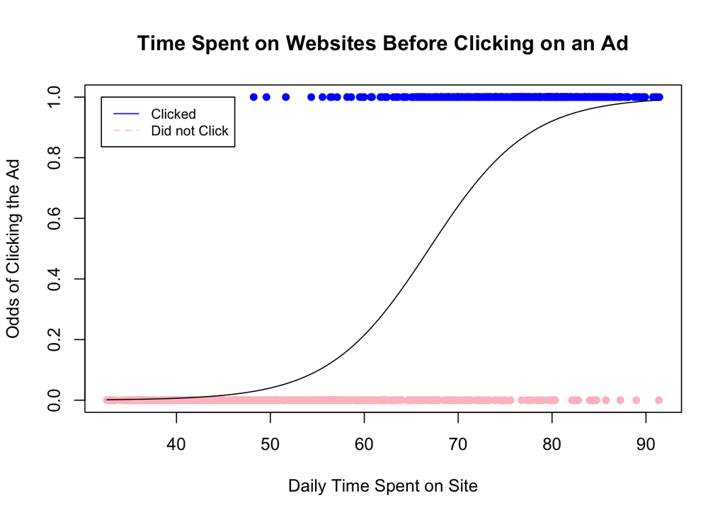

```r
plot(Clicked.on.Ad == "0" ~ Daily.Time.Spent.on.Site, data = Ad, pch = 16, col = ifelse(Clicked.on.Ad == "0", "blue", "pink"), xlab = "Daily Time Spent on Site", ylab = "Odds of Clicking the Ad", main = "Time Spent on Websites Before Clicking on an Ad")
curve(exp(-12.5399+0.1874*x)/(1+exp(-12.5399+0.1874*x)), add = TRUE)
legend(32, 1, legend=c("Clicked", "Did not Click"), col=c("blue", "pink"), lty=1:2, cex=0.8)
```

This plot shows us the odds of clicking, or not clicking, on the ad dependings on how long you spend on a website with that ad present.

```r
pander(summary(Ad.lm))
```

|  | Estimate | Std. Error | z value | Pr(>\|z\|) |
| --- | --- | --- | --- | --- |
| **(Intercept)** | -12.54 | 0.7954 | -15.77 | 5.351e-56 |
| **Daily.Time.Spent.on.Site** | 0.1874 | 0.0115 | 16.29 | 1.108e-59 |

(Dispersion parameter for binomial family taken to be 1 )

| Null deviance: | 1386.3 on 999 degrees of freedom |
| --- | --- |
| Residual deviance: | 647.3 on 998 degrees of freedom |

## Hosmer-Lemeshow Goodness of Fit Test

Since we only have some repeated x values the hosmer-Lemeshow goodness fit test is appropriate to test the fit of the data.

```r
pander(hoslem.test(Ad.lm$y, Ad.lm$fitted, g=7))
```

Hosmer and Lemeshow goodness of fit (GOF) test: `Ad.lm$y, Ad.lm$fitted`

| Test statistic | df | P value |
| --- | --- | --- |
| 21.63 | 5 | 0.0006144 * * * |